# Part 5 Question 1

Part 5 - Advanced Topics

**1. NoSQL replication: push a subset of data to MongoDB, design an appropriate document model, and compare a sample query’s performance vs. PostgreSQL.**

```python
#!pip install pymongo
#!pip install sqlalchemy psycopg2
import psycopg2
import pandas as pd
from sqlalchemy import create_engine
```

Below I will limit to 1000 records as a subset as that size should be big enough to be meaningful, but small enough to demonstrate replication and performance differences clearly.

```python
# Build SQLAlchemy connection URI
engine = create_engine(
    "postgresql+psycopg2://postgres:Python@localhost:5432/nyc_dog_licensing"
)

query = """
SELECT
    d.dog_id,
    d.animal_name,
    d.animal_gender,
    d.animal_birth_year,
    b.breed_name,
    d.zip_id,
    d.license_issued_date
FROM dogs d
JOIN breeds b ON d.breed_id = b.breed_id
LIMIT 1000;
"""

df = pd.read_sql(query, engine)
df.head()
```

|  | dog_id | animal_name | animal_gender | animal_birth_year | breed_name | zip_id | license_issued_date |
| --- | --- | --- | --- | --- | --- | --- | --- |
| 0 | 2 | Yogi | M | 2010 | Boxer | 2 | 2014-09-12 |
| 1 | 3 | Ali | M | 2014 | Basenji | 3 | 2014-09-12 |
| 2 | 4 | Queen | F | 2013 | Akita Crossbreed | 3 | 2014-09-12 |
| 3 | 5 | Lola | F | 2009 | Maltese | 4 | 2014-09-12 |
| 4 | 6 | Ian | M | 2006 | Unknown | 3 | 2014-09-12 |

```python
# Convert Python date objects to ISO strings for MongoDB
df["license_issued_date"] = df["license_issued_date"].astype(str)
```

```python
from pymongo import MongoClient

client = MongoClient("mongodb://localhost:27017")
db = client["nyc_dogs"]
collection = db["dogs_subset"]

collection.insert_many(df.to_dict("records"))

print("Inserted", len(df), "documents into MongoDB.")
```

```
Inserted 1000 documents into MongoDB.
```

Awesome, 1000 rows were pushed into MongoDB and have fulfilled the requirements to push a subset of data to MongoDB.

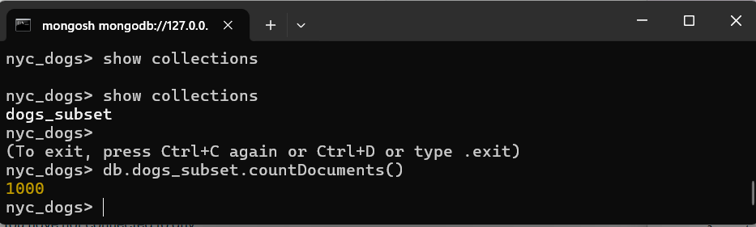

**Compare a sample query’s performance vs. PostgreSQL.**

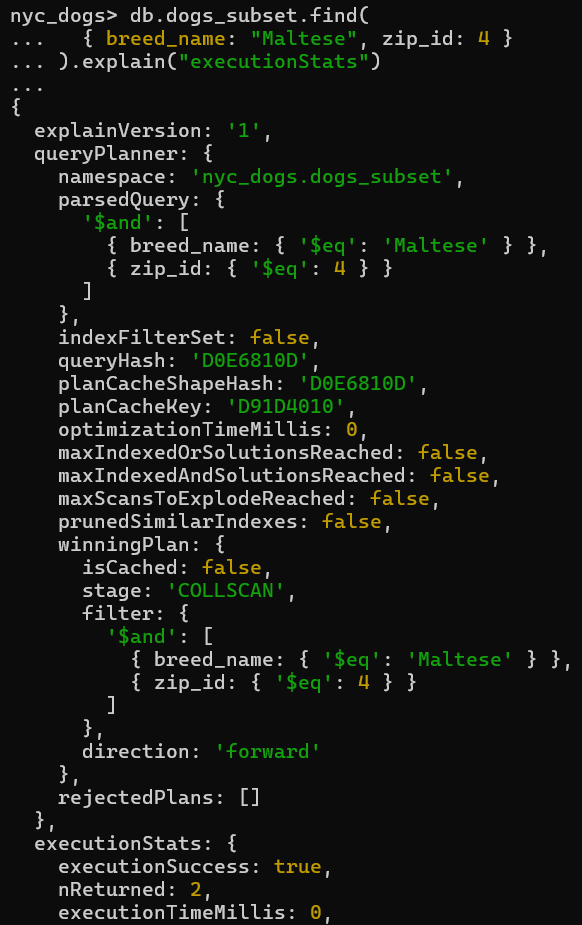

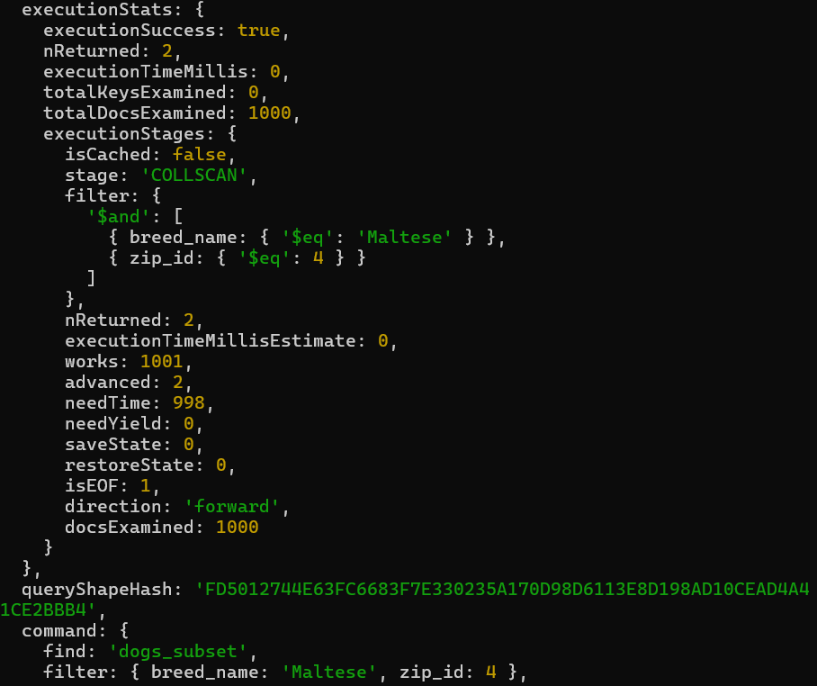

Looking at the output of MongoDB:

For "stage": it used a "COLLSCAN," which means it performed a full collection scan, and examined all 1,000 documents, and filtered them one by one. This is also confirmed as the output shows: "docsExamined: 1000" and "totalKeysExamined: 0" notifying that every document in the collection was scanned. As I have not created an index, no index was used.

For performance numbers, "executionTimeMillis: 0" which means MongoDB is fast enough that a 1,000 document scan took under 1 millisecond, so it reported 0.

**Below I will add an INDEX**

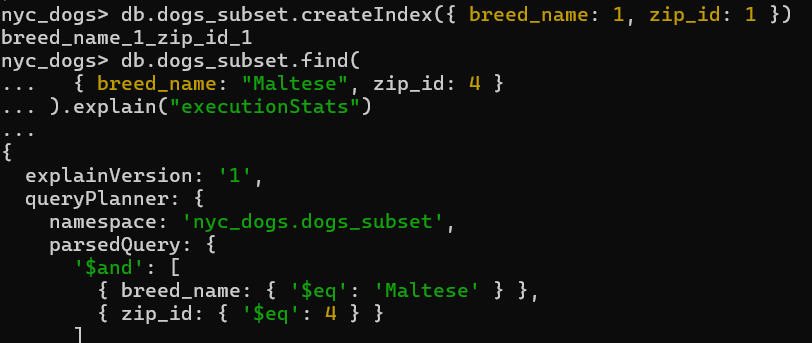

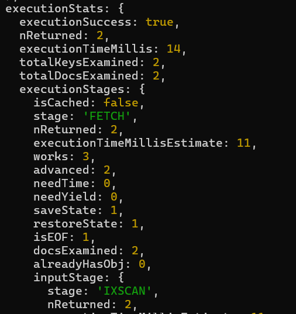

Using an index increased the reported execution time from 0 ms to 14 ms. This does not mean the index made the query slower; rather, the difference is due to the very small dataset size. Scanning 1,000 documents entirely in RAM is extremely cheap, so MongoDB rounds the execution time down to 0 ms. Once the index was added, MongoDB performed additional planning and index traversal steps, which introduce overhead that becomes noticeable at very small scales. If the dataset were much larger such as 500,000 or more documents, the indexed query would outperform the full collection scan, because the index would avoid scanning the entire collection and would examine only the matching keys.

Now we can take a look at PostgreSQL

[figure not shown]

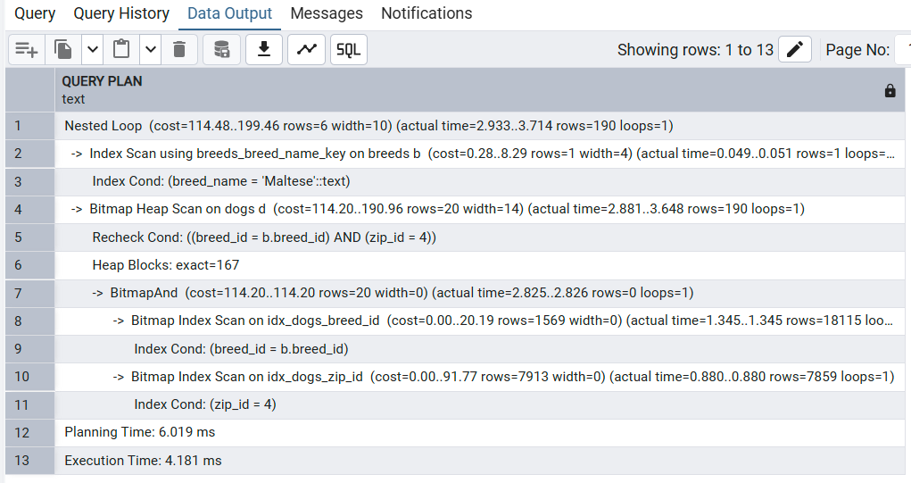

Looking at PostgreSQL’s query behavior, the EXPLAIN ANALYZE output shows that the database correctly used index scans rather than a full sequential scan. However, PostgreSQL still had to process thousands of matching index entries before filtering. The lines "rows=18115 loops=1" and "rows=7859 loops=1" indicate that approximately 18,115 dogs matched the breed condition, while 7,859 dogs matched the ZIP code condition. PostgreSQL combined these via a BitmapAnd operation and then completed the join with a Nested Loop. Despite being fully indexed, this multi-step process required more work than expected. The planning phase took 6.019 ms, and the query execution itself completed in 4.181 ms.

**Conclusion:** This experiment compared query performance between PostgreSQL and MongoDB using the same lookup conditions. PostgreSQL operated on the full relational dataset and used multiple index scans along with a BitmapAnd operation. Although fully indexed, PostgreSQL still had to evaluate a large number of matching index entries, approximately 18,115 breed matches and 7,859 ZIP code matches before applying filtering and completing the join. The query executed in 4.181 ms, but required significantly more internal processing.

In conclusion, while PostgreSQL remains highly optimized for relational workloads and complex join operations, MongoDB’s denormalized model enables extremely efficient point lookups when the data is structured to match the query pattern. With larger datasets, the index-driven MongoDB approach would scale more efficiently for this type of lookup, whereas PostgreSQL would continue to incur join and bitmap filtering costs. The results highlight that database performance is highly dependent on data model design and query patterns rather than raw execution time alone.